# Deep Learning

## Face Recognition

Welcome to the first project of the Machine Learning Engineer Nanodegree! In this notebook, some template code has already been provided for you, and you will need to implement additional functionality to successfully complete this project. You will not need to modify the included code beyond what is requested. Sections that begin with **'Implementation'** in the header indicate that the following block of code will require additional functionality which you must provide. Instructions will be provided for each section and the specifics of the implementation are marked in the code block with a 'TODO' statement. Please be sure to read the instructions carefully!

In addition to implementing code, there will be questions that you must answer which relate to the project and your implementation. Each section where you will answer a question is preceded by a **'Question X'** header. Carefully read each question and provide thorough answers in the following text boxes that begin with **'Answer:'**. Your project submission will be evaluated based on your answers to each of the questions and the implementation you provide.

> **Note:** Code and Markdown cells can be executed using the **Shift + Enter** keyboard shortcut. In addition, Markdown cells can be edited by typically double-clicking the cell to enter edit mode.

## Getting Started

The face_recognition library is widely known around the web for being the world's simplest facial recognition api for Python and the command line, and the best of all is that you won't need to pay a dime for it, the project is totally open source, so if you have some development knowledge and you are able to build a library from scratch, you'll surely know how to work with this library.

```
# Update repo
sudo apt-get update

# Install cmake if it's not installed
sudo apt-get install build-essential cmake

# Clone the dlib library in some directory of the system
git clone https://github.com/davisking/dlib.git

# get into the cloned directory
cd dlib

# create build directory inside the cloned directory
mkdir build

# Switch to the created directory
cd build

# generate a Makefile in the current directory
cmake ..

# Build dlib !
cmake --build .
cd ..

python3 setup.py install

pip3 install face_recognition

sudo apt-get -y install python3-pip
```

## Import libraries

```python
from matplotlib.pyplot import imshow
import numpy as np
from pathlib import Path

import PIL.Image
import PIL.ImageDraw
import face_recognition

%matplotlib inline

# Load the jpg file into a numpy array
image = face_recognition.load_image_file("images/people.jpg")
```

## Face detection

Because most human faces have roughly the same structure, the pre-trained face detection model will work well for almost any image. There's no need to train a new one from scratch. First, notice on line one, I've already imported the PIL library's image class, and then the image draw class. PIL is the Python Image Library. It lets us easily display an image on the screen, and draw lines on top of the image. We'll use it to display the results of our face detection code. To perform face detection with this library, we just need to load an image file, and then run the image file through the model.

```
I found 6 face(s) in this photograph.
A face is located at pixel location Top: 163, Left: 497, Bottom: 271, Right: 605
A face is located at pixel location Top: 186, Left: 275, Bottom: 275, Right: 364
A face is located at pixel location Top: 211, Left: 67, Bottom: 319, Right: 175
A face is located at pixel location Top: 295, Left: 653, Bottom: 402, Right: 760
A face is located at pixel location Top: 271, Left: 366, Bottom: 378, Right: 474
A face is located at pixel location Top: 152, Left: 724, Bottom: 259, Right: 832
```

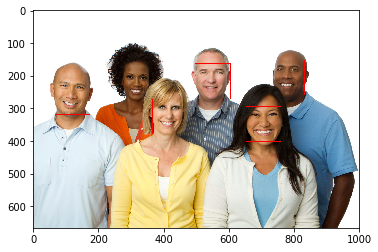

```python
# Find all the faces in the image
face_locations = face_recognition.face_locations(image)

number_of_faces = len(face_locations)
print("I found {} face(s) in this photograph.".format(number_of_faces))

# Load the image into a Python Image Library object so that we can draw on top of it and display it
pil_image = PIL.Image.fromarray(image)

for face_location in face_locations:
    # Print the location of each face in this image. Each face is a list of co-ordinates in (top, right, bottom, left) order.
    top, right, bottom, left = face_location
    print("A face is located at pixel location Top: {}, Left: {}, Bottom: {}, Right: {}".format(top, left, bottom, right))

    # Let's draw a box around the face
    draw = PIL.ImageDraw.Draw(pil_image)
    draw.rectangle([left, top, right, bottom], outline="red")

# Display the image on screen
# pil_image.show()
imshow(np.asarray(pil_image))
```

We'll be using PIL, or the Python Image Library to display and draw on top of our image so that we can see each facial feature that we detect. We'll call face_recognition.face_landmarks then we'll pass in the array with the image data, which we called image. Then we'll capture the result as a variable. Well call it face_landmarks_list equals that function call. The result of the function is a list that contains entry for each face found in the image. If no faces were found in the image, the list will be empty. Otherwise, there will be one set of face landmarks for each face that was in the image. Each face will be a Python dictionary object. It's similar to a hashmap or a hashtable in other programming languages. The keys of the dictionary are the names of the facial feature.

```
I found 6 face(s) in this photograph.
```

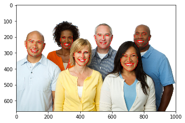

```python
# Find all facial features in all the faces in the image
face_landmarks_list = face_recognition.face_landmarks(image)

number_of_faces = len(face_landmarks_list)
print("I found {} face(s) in this photograph.".format(number_of_faces))

# Load the image into a Python Image Library object so that we can draw on top of it and display it
pil_image = PIL.Image.fromarray(image)

# Create a PIL drawing object to be able to draw lines later
draw = PIL.ImageDraw.Draw(pil_image)

# Loop over each face
for face_landmarks in face_landmarks_list:

    # Loop over each facial feature (eye, nose, mouth, lips, etc)
    for name, list_of_points in face_landmarks.items():

        # Print the location of each facial feature in this image
        #print("The {} in this face has the following points: {}".format(name, list_of_points))

        # Let's trace out each facial feature in the image with a line!
        draw.line(list_of_points, fill="red", width=2)

# Display the image on screen
# pil_image.show()
imshow(np.asarray(pil_image))
```

## Face encodings

```python
# Generate the face encodings
face_encodings = face_recognition.face_encodings(image)

if len(face_encodings) == 0:
    # No faces found in the image.
    print("No faces were found.")

else:
    # Grab the first face encoding
    first_face_encoding = face_encodings[0]

    # Print the results
    print(first_face_encoding)
```

```
[-0.08102002  0.19778648  0.10116202 -0.10768926 -0.08938848 -0.0051124
 -0.02069698 -0.01189597  0.13854286  0.05478634  0.26563567 -0.00901977
 -0.27633318 -0.10323296 -0.13193214  0.20519768 -0.17141552 -0.0534021
 -0.17822698 -0.03385314  0.06798737  0.06815895 -0.02067376  0.01341064
 -0.0798282  -0.29371518 -0.02055131 -0.09726715  0.00150193 -0.13555917
 -0.01348892  0.149285   -0.10260151 -0.09903324  0.04098056  0.04845271
 -0.0095956   0.01337791  0.16898043  0.06358174 -0.13881597  0.08453506
  0.07367077  0.31221765  0.20606795  0.05827205  0.08826714 -0.06527514
  0.12916695 -0.30328029  0.01255909  0.14367844  0.13355717  0.12681633
  0.10245252 -0.15223342 -0.00435856  0.17431585 -0.14850871  0.09651553
  0.02589577 -0.18498759 -0.05150758 -0.09657746  0.15796225  0.03747438
 -0.12108739 -0.03004657  0.16765036 -0.06757218 -0.09263331  0.03642856
 -0.10270913 -0.10475127 -0.3123022   0.06945308  0.35907561  0.19123578
 -0.27626169 -0.03136463 -0.07415473  0.01194138  0.01295551  0.04154692
 -0.12049517  0.00056301 -0.09705911 -0.025439    0.19808058 -0.04125846
  0.04991501  0.27287465  0.08834448  0.04505213  0.00306252 -0.02003714
 -0.05329881 -0.10552815 -0.1550615  -0.02519462 -0.02214642 -0.14227265
 -0.03580544  0.03146038 -0.1764942   0.09570234  0.01675246 -0.0183524
 -0.09773493 -0.00579502  0.00135526  0.00874165  0.20599724 -0.15631157
  0.20649248  0.24789079  0.04725068  0.10755037  0.11051724  0.0518211
 -0.0382682  -0.09127116 -0.00967917 -0.13161682  0.13282856 -0.02059512
  0.0397763   0.00900745]
```

## Face recognition

Let's code a real face recognition system.

First we need pictures of the people that we wanna be able to recognize. I've included sample photos of three people in the project. For pictures of known people, you wanna make sure that there's only one person in the picture and that they are facing the camera, clearly visible, and that there's reasonably good lighting. If you use lower-quality images, the results won't be as accurate.

Instead of just grabbing the first face encoding like we did with our known images, we'll loop over all the face encodings using a for loop. For unknown_face_encoding in unknown_face_encodings, then we can look at each face encoding we find in the unknown image. Now we're ready to compare the known and unknown face encodings. We can do that using the compare_faces function. First we need to pass in our array of known face encodings. We'll pass that in here as the first parameters for our function, and then we need to pass in our unknown face encoding. So we'll pass in unknown_face_encoding from this loop and then we'll save that in a variable called results.

```
Found Person 2 in the photo!
Found Person 1 in the photo!
Found Person 3 in the photo!
```

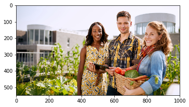

```python
# Load the known images
image_of_person_1 = face_recognition.load_image_file("images/person_1.jpg")
image_of_person_2 = face_recognition.load_image_file("images/person_2.jpg")
image_of_person_3 = face_recognition.load_image_file("images/person_3.jpg")

# Get the face encoding of each person. This can fail if no one is found in the photo.
person_1_face_encoding = face_recognition.face_encodings(image_of_person_1)[0]
person_2_face_encoding = face_recognition.face_encodings(image_of_person_2)[0]
person_3_face_encoding = face_recognition.face_encodings(image_of_person_3)[0]

# Create a list of all known face encodings
known_face_encodings = [
    person_1_face_encoding,
    person_2_face_encoding,
    person_3_face_encoding
]

# Load the image we want to check
unknown_image = face_recognition.load_image_file("images/unknown_2.jpg")

# Get face encodings for any people in the picture
unknown_face_encodings = face_recognition.face_encodings(unknown_image)

# There might be more than one person in the photo, so we need to loop over each face we found
for unknown_face_encoding in unknown_face_encodings:

    # Test if this unknown face encoding matches any of the three people we know
    results = face_recognition.compare_faces(known_face_encodings, unknown_face_encoding, tolerance=0.6)

    name = "Unknown"

    if results[0]:
        name = "Person 1"
    elif results[1]:
        name = "Person 2"
    elif results[2]:
        name = "Person 3"

    print(f"Found {name} in the photo!")

imshow(np.asarray(unknown_image))
```

## Applying digital makeup to a face

Our face recognition pipeline has the ability to detect face landmarks. Let's see how we can use face landmarks to do something fun, let's use them to create digital makeup. If you've used any social media applications like Instagram or Snapchat, you might've seen how you can add silly effects to your pictures to make it look like you're wearing makeup or funny hats. Let's create a really simple version of that.

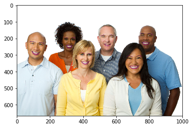

```python
# Find all facial features in all the faces in the image
face_landmarks_list = face_recognition.face_landmarks(image)

# Load the image into a Python Image Library object so that we can draw on top of it and display it
pil_image = PIL.Image.fromarray(image)

# Create a PIL drawing object to be able to draw lines later
d = PIL.ImageDraw.Draw(pil_image, 'RGBA')

for face_landmarks in face_landmarks_list:
    # The face landmark detection model returns these features:
    #  - chin, left_eyebrow, right_eyebrow, nose_bridge, nose_tip, left_eye, right_eye, top_lip, bottom_lip

    # Draw a line over the eyebrows
    d.line(face_landmarks['left_eyebrow'], fill=(128, 0, 128, 100), width=3)
    d.line(face_landmarks['right_eyebrow'], fill=(128, 0, 128, 100), width=3)

    # Draw over the lips
    d.polygon(face_landmarks['top_lip'], fill=(128, 0, 128, 100))
    d.polygon(face_landmarks['bottom_lip'], fill=(128, 0, 128, 100))

# Show the final image
# pil_image.show()
imshow(np.asarray(pil_image))
```

## Finding lookalikes with face recognition

Let's see how we can use face recognition to find lookalikes. Imagine that you wanted to find out which celebrity looks the most like you. You could do that with face recognition by comparing your face to pictures of celebrities. But instead of using face recognition to check for an exact match, you could use it to find out which face is the most similar. The picture with the smallest "face_distance" from your picture should be the celebrity that looks the most like you.

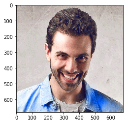

```python
# Load the image of the person we want to find similar people for
known_image = face_recognition.load_image_file("images/test_face.jpg")

# Encode the known image
known_image_encoding = face_recognition.face_encodings(known_image)[0]

# Variables to keep track of the most similar face match we've found
best_face_distance = 1.0
best_face_image = None

# Loop over all the images we want to check for similar people
for image_path in Path("images/people").glob("*.png"):
    # Load an image to check
    unknown_image = face_recognition.load_image_file(image_path)

    # Get the location of faces and face encodings for the current image
    face_encodings = face_recognition.face_encodings(unknown_image)

    # Get the face distance between the known person and all the faces in this image
    face_distance = face_recognition.face_distance(face_encodings, known_image_encoding)[0]

    # If this face is more similar to our known image than we've seen so far, save it
    if face_distance < best_face_distance:
        # Save the new best face distance
        best_face_distance = face_distance
        # Extract a copy of the actual face image itself so we can display it
        best_face_image = unknown_image

# Display the face image that we found to be the best match!
pil_image = PIL.Image.fromarray(best_face_image)

# Show the final image
# pil_image.show()
imshow(np.asarray(pil_image))
```